# STAT435 hw7

Haoran Yu

May 21, 2018

## Problem 1

#### (a)

```r
dat = read.csv("D:\\class\\STAT435\\homework 7\\wine.csv", sep = ";", header = T)
```

I get this data from UCI machine learning repository. This data is about the wine’s pH and its physicochemical feature. The response Y is the pH of wine, which is quantitative. The features x1 is the fixed acidity of the wine, x2 is the volatile acidity of the wine, x3 is the citric acid of the wine. All features are quantitative. The value of n is 1599 and the value of p is 3.

#### (b)

```r
fit = mgcv::gam(pH ~ s(fixed.acidity) + s(volatile.acidity) + s(citric.acid), data = dat)
fit
```

```
##
## Family: gaussian
## Link function: identity
##
## Formula:
## pH ~ s(fixed.acidity) + s(volatile.acidity) + s(citric.acid)
##
## Estimated degrees of freedom:
## 8.26 2.59 5.99  total = 17.84
##
## GCV score: 0.01056359
```

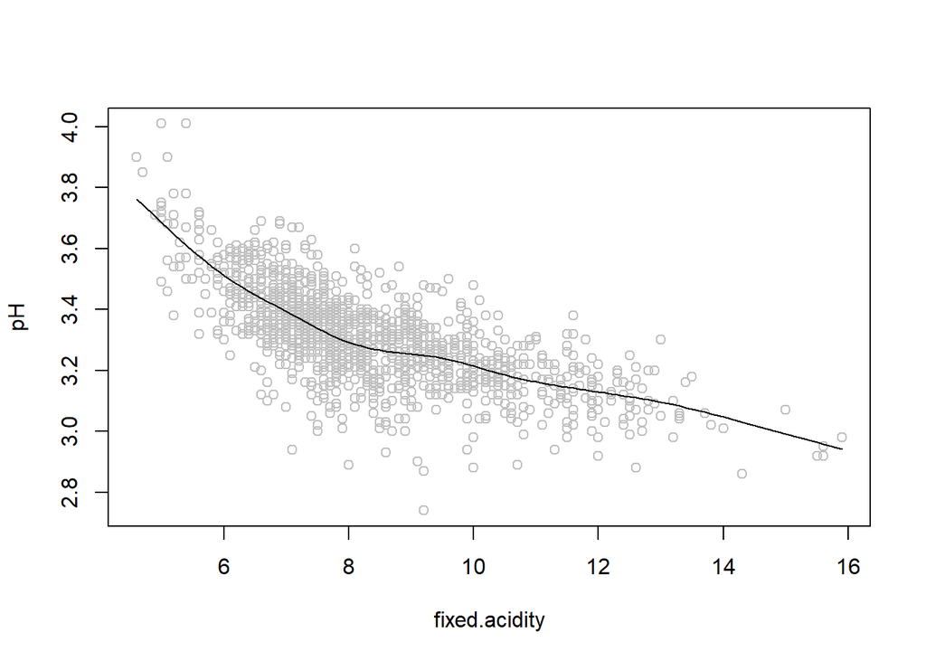

```r
fit1 = smooth.spline(dat$fixed.acidity, dat$pH, df = 8.26)
plot(dat$fixed.acidity, dat$pH, col = "grey", xlab = "fixed.acidity", ylab = "pH")
lines(fit1)
```

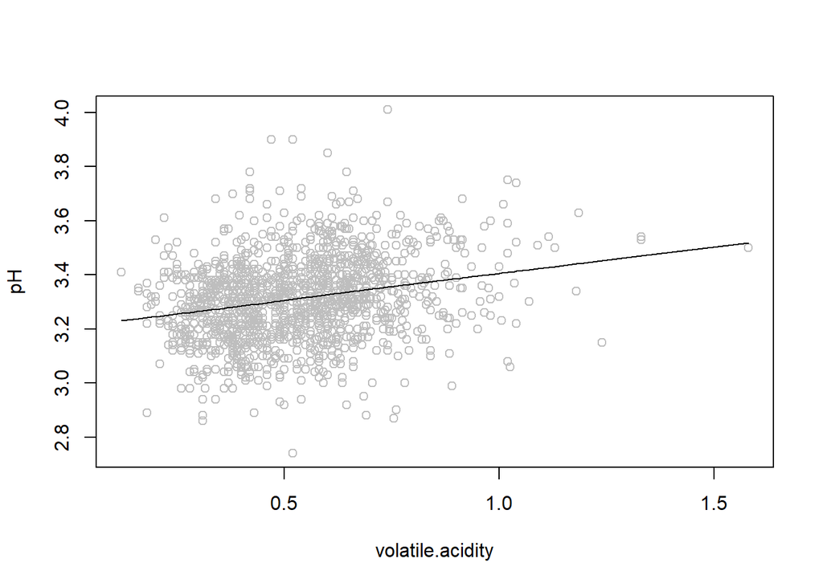

```r
fit2 = smooth.spline(dat$volatile.acidity, dat$pH, df = 2.59)
plot(dat$volatile.acidity, dat$pH, col = "grey", xlab = "volatile.acidity", ylab = "pH")
lines(fit2)
```

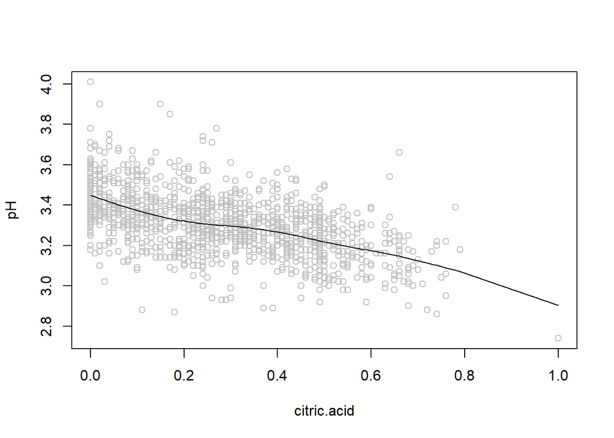

```r
fit3 = smooth.spline(dat$citric.acid, dat$pH, df = 5.99)
plot(dat$citric.acid, dat$pH, col = "grey", xlab = "citric.acid", ylab = "pH")
lines(fit3)
```

I choose smooth spline with 8.26 degree of freedom for fixed acidity, smooth spline with 2.59 degree of freedom for volatile acidity, and smooth spline with 5.99 degree of freedom for citric acid when I made in fitting this model.

#### (c)

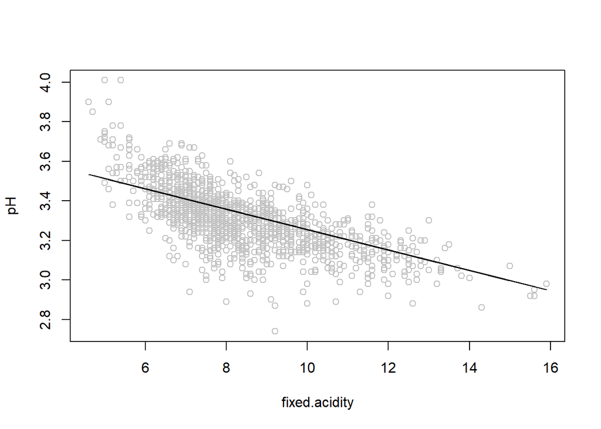

```r
lm.1 = lm(pH ~ fixed.acidity + volatile.acidity + citric.acid, data = dat)
plot(dat$fixed.acidity, dat$pH, col = "grey", xlab = "fixed.acidity", ylab = "pH")
lines(dat$fixed.acidity, (lm.1$coeff[1]+lm.1$coeff[2]*dat$fixed.acidity))
```

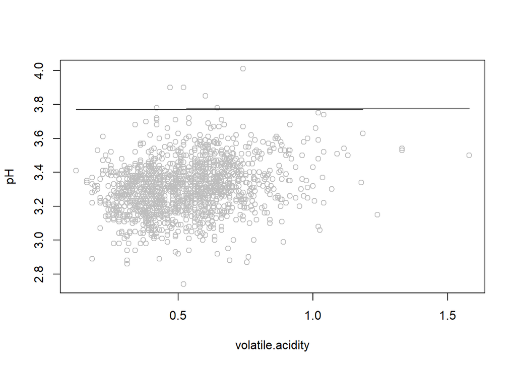

```r
plot(dat$volatile.acidity, dat$pH, col = "grey", xlab = "volatile.acidity", ylab = "pH")
lines(dat$volatile.acidity, (lm.1$coeff[1]+lm.1$coeff[3]*dat$volatile.acidity))
```

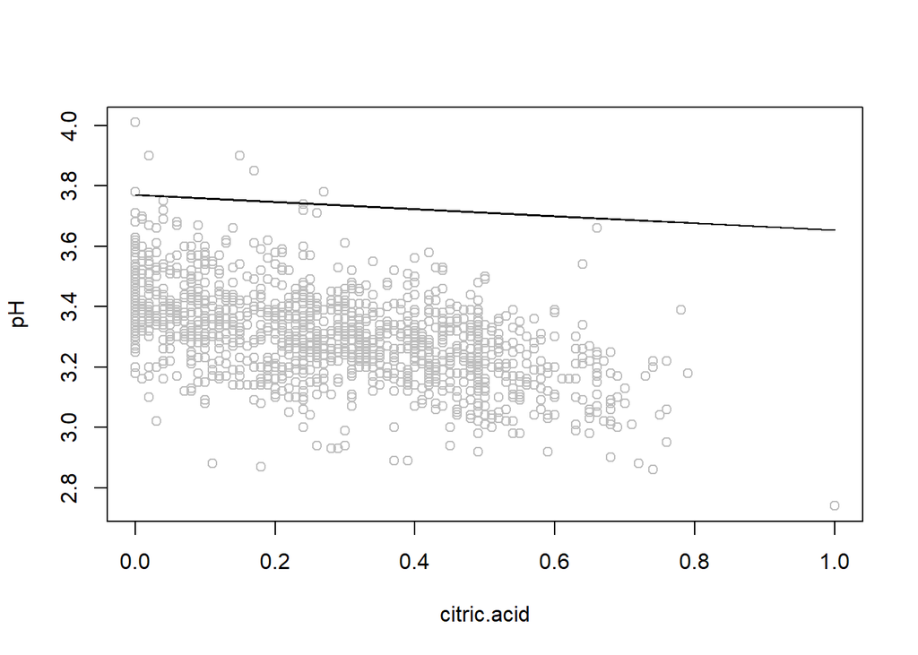

```r
plot(dat$citric.acid, dat$pH, col = "grey", xlab = "citric.acid", ylab = "pH")
lines(dat$citric.acid, (lm.1$coeff[1]+lm.1$coeff[4]*dat$citric.acid))
```

#### (d)

```r
dat1 = dat[1:1000, ]
dat2 = dat[1001:1599, ]
fit = mgcv::gam(pH ~ s(fixed.acidity) + s(volatile.acidity) + s(citric.acid), data = dat1)
pred1 = predict(fit, dat2)
lm.1 = lm(pH ~ fixed.acidity + volatile.acidity + citric.acid, data = dat1)
pred2 = predict(lm.1, dat2)
mean((dat2$pH - pred1)^2)
```

```
## [1] 0.01110035
```

```r
mean((dat2$pH - pred2)^2)
```

```
## [1] 0.01244565
```

The test error of the generalized additive model is 0.01110035, the test error of the linear model is 0.01244565, the generalized additive model gives a better fit to the data.

## Problem 2

#### (a)

```r
set.seed(7)
x = 1:1000
error = rnorm(1000)
y = sin((1:1000)/100)*4+error
var(error)
```

```
## [1] 0.964956
```

```r
mean(error^2)
```

```
## [1] 0.9640003
```

The form of $f(x)$ for this simulation setting is $4sin(\frac{x}{100})$. The value of $Var(\epsilon)$ is 0.964956, and the value of $E(Y-f(x))^2$ is 0.9640003.

#### (b)

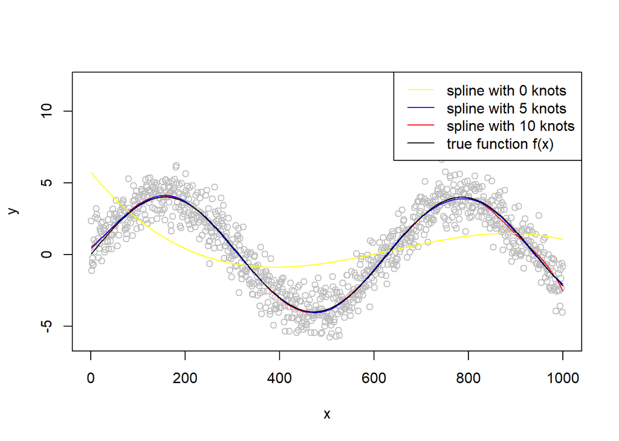

```r
library(splines)
plot(x, y, col = "gray", ylim = c(-6, 12))
fit = lm(y ~ bs(x, df = 13))
pred3 = predict(fit, se = T)
lines(x, pred3$fit, col = "red")
fit = lm(y ~ bs(x, df = 8))
pred5 = predict(fit, se = T)
lines(x, pred5$fit, col = "blue")
fit = lm(y ~ bs(x, df = 3))
pred1 = predict(fit, se = T)
lines(x, pred1$fit, col = "yellow")
lines(x, sin(x/100)*4)
legend('topright', c('spline with 0 knots', 'spline with 5 knots', 'spline with 10 knots', 'true function f(x)'), col = c("yellow", "blue", "red", "black"), lty = 1)
```

#### (d)

[figure not shown]

```r
library(boot)
set.seed(123)
xnew = sample(1:1000, 1000)
mse = numeric(20)
cv = numeric(20)
dat = data.frame(x = x, y = y)
for (i in 1:20) {
  for (j in 1:10) {
    test = dat[xnew[((j-1)*100+1):(j*100)], ]
    train = dat[-xnew[(((j-1)*100+1):(j*100))], ]
    fit = lm(y ~ bs(x, df = 3+i), data = train)
    pred = predict(fit, newdata = test)
    mse[j] = mean((test$y - pred)^2)
  }
  cv[i] = mean(mse)
}
plot(1:20, cv, type = 'l', xlab = "num of knots", ylab = "test MSE")
```

```r
which.min(cv)
```

```
## [1] 5
```

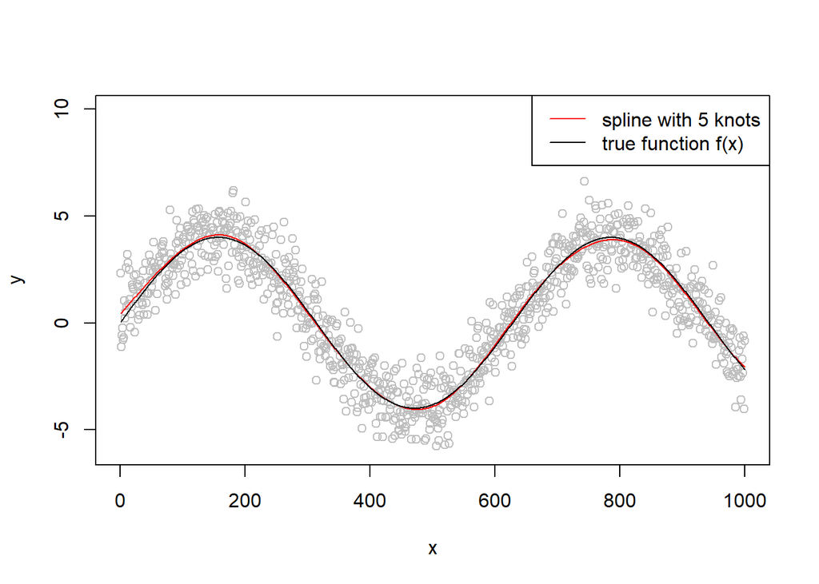

```r
fit = lm(y ~ bs(x, df = 8))
pred5 = predict(fit, se = T)
plot(x, y, col = "gray", ylim = c(-6, 10))
lines(x, pred5$fit, col = "red")
lines(x, sin(x/100)*4)
legend('topright', c('spline with 5 knots', 'true function f(x)'), col = c("red", "black"), lty = 1)
```

The best number of knots is 5.

#### (e)

```r
dat1 = dat[xnew[1:200], ]
dat2 = dat[-xnew[1:200], ]
fit = lm(y ~ bs(x, df = 8), data = dat1)
pred = predict(fit, newdata = dat2)
mean((dat2$y-pred)^2)
```

```
## [1] 0.9966391
```

The estimate of the test error is 0.9966391, and it is slightly larger than my answer in (a).

#### (f)

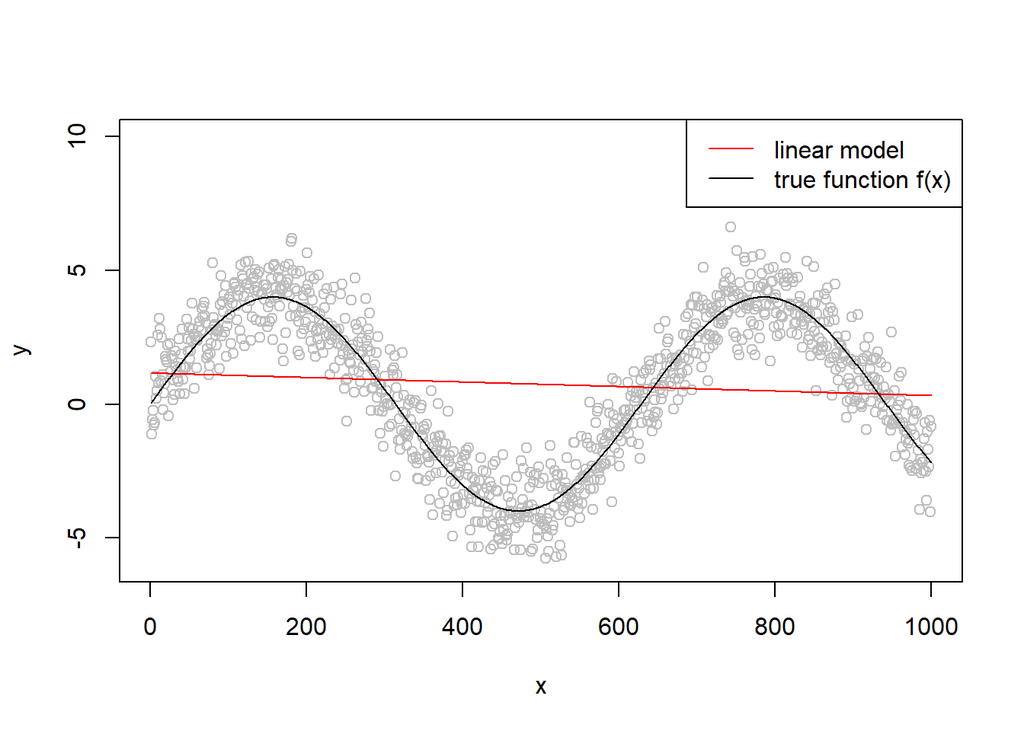

```r
lm.1 = lm(y ~ x)
lm.pred = predict(lm.1)
plot(x, y, col = "gray", ylim = c(-6, 10))
lines(x, lm.pred, col = "red")
lines(x, sin(x/100)*4)
legend('topright', c('linear model', 'true function f(x)'), col = c("red", "black"), lty = 1)
```

```r
dat1 = dat[xnew[1:200], ]
dat2 = dat[-xnew[1:200], ]
lm.1 = lm(y ~ x, data = dat1)
pred = predict(lm.1, dat2)
mean((dat2$y-pred)^2)
```

```
## [1] 8.080151
```

The estimate of the test error is 8.080151, and it is much larger than my answer in (a), also it is much larger than the test error I estimated for regression spline.